# MI Wave 1 analyses: JNeuro reanalysis/replication

# 1 intro

```r
## libraries ----

library(here)
library(data.table)
source(here("src", "stroop-rsa-pc.R"))
library(knitr)
library(dplyr)
library(tidyr)
library(ggplot2)
library(mfutils)
library(ggseg)
library(ggsegExtra)
library(ggsegSchaefer)
library(ggsegGlasser)

## settings, params ----

opts_chunk$set(echo = TRUE, out.width = "100%")
theme_set(theme_bw(base_size = 10))

if (exists("params")) {
  ttype_subset <- params$ttype_subset
  prewh <- params$prewh
  measure <- params$measure
  roiset <- params$roiset
} else {
  ttype_subset <- "bias"
  prewh <- "obsall"
  measure <- "cveuc"
  roiset <- "glasser2016_parcel"
}

theme_surface <- list(
  theme(
    axis.text = element_blank(), panel.grid = element_blank(), panel.border = element_blank(),
    axis.ticks = element_blank(), legend.position = c(0.5, 0.5), legend.title = element_text(size = 5),
    legend.background = element_blank(), legend.text = element_text(size = 5), legend.direction = "horizontal",
    legend.key.height = unit(1/5, "cm"), legend.key.width = unit(1/4, "cm")
  )
)


## constants ----

wd <- here()
subjlists <- "mi1"
seswaves <- c("proactive_wave1")
glmname <- "lsall_1rpm"
sessions <- c("proactive")
statistics <- c("m", "t_stat")
titles <- c("mean coefficient", "t statistic")


## data ----

## read regression weights:

dat <- Map(
  function(subjlist, suffix) {
    fname <- construct_filename_weights(
        measure = measure, subjlist = subjlist, glmname = glmname,
        ttype_subset = ttype_subset, roiset = roiset, prewh = prewh, suffix = suffix
        )
    fread(fname)
  },
  subjlist = subjlists,
  suffix = paste0("__seswave-", seswaves)
)
dat <- rbindlist(dat)


## get ggseg atlas and format data to match:

dat <- dat %>% rename(region = roi)

if (roiset == "schaefer2018_17_200_parcel") {

  atlas <- schaefer17_200
  k <- schaefer2018_17_200_fsaverage5$key %>% select(region = parcel, network)

  rois <- data.frame(
    region = c(
    "17Networks_LH_ContA_PFClv_1",
    "17Networks_LH_ContA_PFCl_1",
    "17Networks_LH_ContA_PFCl_2",
    "17Networks_LH_ContA_PFCl_3",
    "17Networks_RH_ContA_PFCl_1",
    "17Networks_RH_ContA_PFCl_2",
    "17Networks_LH_SalVentAttnB_PFCmp_1",
    "17Networks_RH_SalVentAttnB_PFCmp_1",
    "17Networks_LH_SalVentAttnA_FrMed_1",
    "17Networks_RH_SalVentAttnA_FrMed_1"
    ),
    location = c(rep("lateral", 6), rep("medial", 4))
  )

} else if (roiset == "glasser2016_parcel") {

  atlas <- glasser
  k <- glasser2016_fsaverage5$key %>% select(region = parcel, network)

  dat <- dat %>% filter(!region %in% "L_10pp")  ## not in glasser ggseg atlas?
  ## create region column in ggseg atlas that matches data:
  hemi <- ifelse(atlas$data$hemi == "left", "L_", "R_")
  atlas$data$region <- ifelse(is.na(atlas$data$region), NA, paste0(hemi, atlas$data$region))

  rois <- data.frame(
    region = combo_paste(c("L_", "R_"), c("SCEF", "8BM",  "p32pr", "a32pr", "p9-46v", "i6-8", "8Av", "8C")),
    location = c(rep("medial", 8), rep("lateral", 8))
  )

}

## add network information:
atlas$data <- left_join(atlas$data, k, by = "region")
dat <- left_join(dat, k, by = "region")


## calculate ----

## add subject set information:
subjlists <- rbind(
  data.table(subjlist = "jneurosci", subject = fread(here("out", "subjlist_jneurosci_primary.txt"))[[1]]),
  data.table(subjlist = "replication", subject =
               fread(here("out", "subjlist_jneurosci_replication_primary.txt"))[[1]])
)
dat_subjs <- dat %>% inner_join(subjlists, by = "subject")
dat_subjs <- bind_rows(dat_subjs, dat_subjs %>% mutate(subjlist = "jneurosci \u222A replication"))

dat_sum <- dat_subjs %>%
  group_by(subjlist, session, term, wave, region) %>%
  summarize(
    m = mean(b),
    t_stat = t.test(b)$statistic,
    p = t.test(b, alternative = "greater")$p.value,
    .groups = "drop_last"
    ) %>%
  mutate(p_fdr = p.adjust(p, "fdr"))

dat_sum <- dat_sum %>% filter(term %in% models[[measure]])

n_subjs <- table(unique(dat_subjs[, c("subject", "subjlist")])$subjlist)
```

This file displays group-level RSA model coefficients (means, test statistics).

**Analysis parameters**:

- Item type: bias
- Prewhitening type: obsallave
- Similarity measure: crcor
- ROI set: schaefer2018_17_200_parcel

**Subject samples**:

Analyses are conducted with three different sets of subjects.

- the **jneurosci** set: N = 46, unrelated
  - The paper had N=49; 3 subjects are not included in these analyses: 873968, DMCC1971064, DMCC9478705
  - the latter subject is not included due to failed fmriprep preprocessing
  - the former two subjects were unintentionally excluded due to meeting jo’s criteria for “bad runs”: >20% of TRs excluded due to high motion (I am running these subjects now)
- the **replication** set: N = 21, unrelated (to each other and to those in jneurosci)
- the **jneurosci** $\bigcup$ **replication** set: N = 67, unrelated

# 2 Brains

## 2.1 Unthresholded

### 2.1.1 Common scale

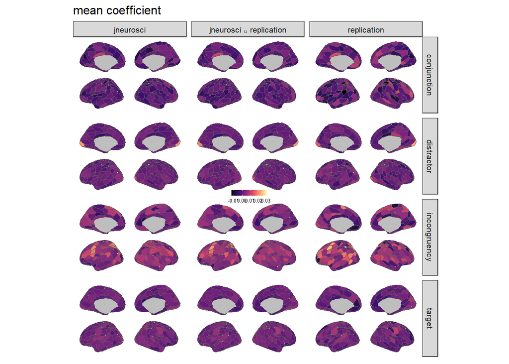

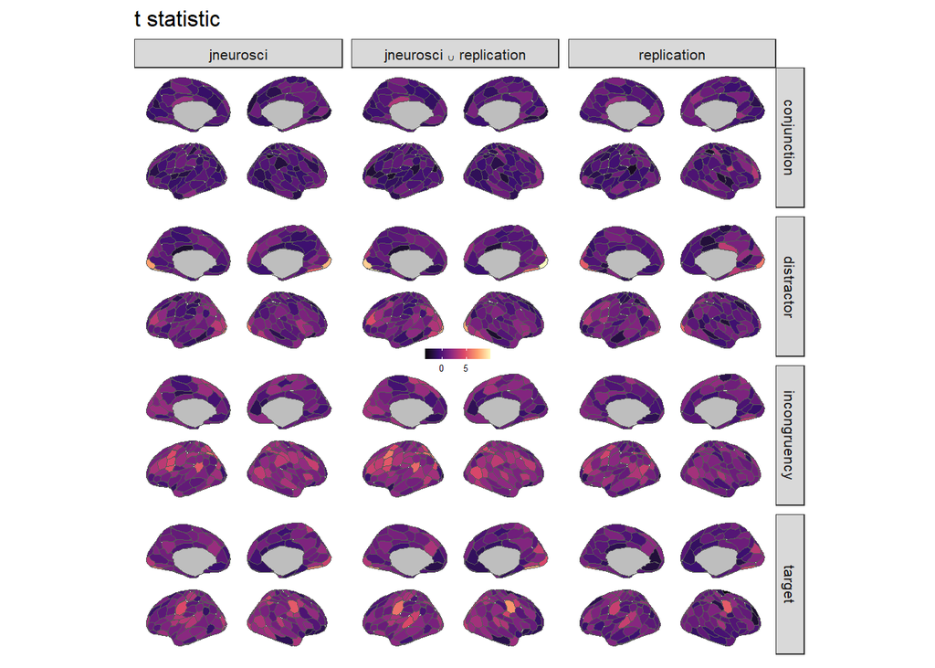

```r
for (stat_i in seq_along(statistics)) {

  p <- dat_sum %>%
    ggplot() +
    geom_brain(
      aes_string(fill = statistics[stat_i]),
      atlas = atlas, position = position_brain(side ~ hemi)
      ) +
    scale_fill_viridis_c(
      option = "magma", na.value = "grey",
      breaks = scales::extended_breaks(4)
      ) +
    facet_grid(rows = vars(term), cols = vars(subjlist)) +
    theme_surface +
    labs(title = titles[stat_i], fill = NULL)

  print(p)

}
```

### 2.1.2 Separate scales by model

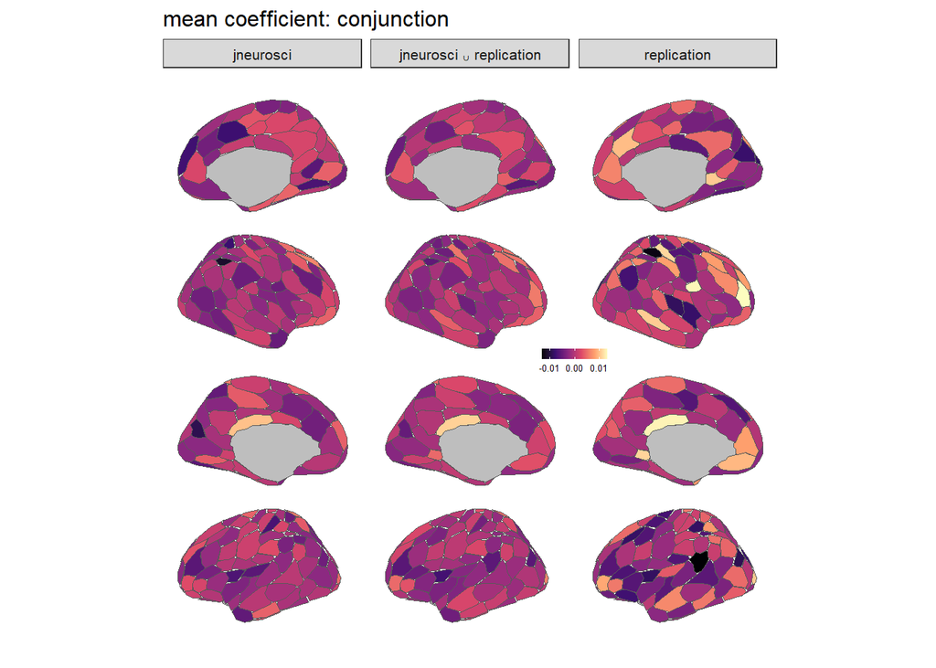

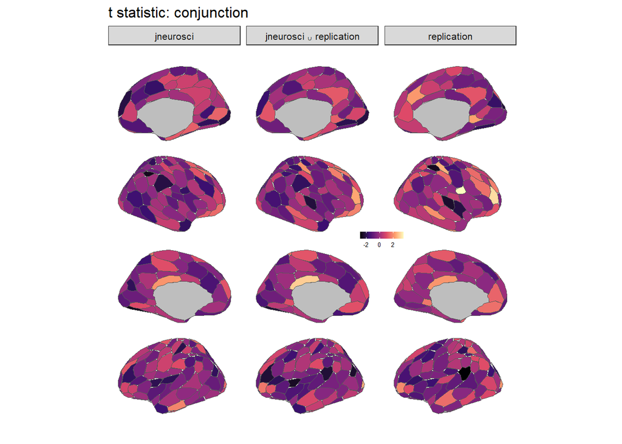

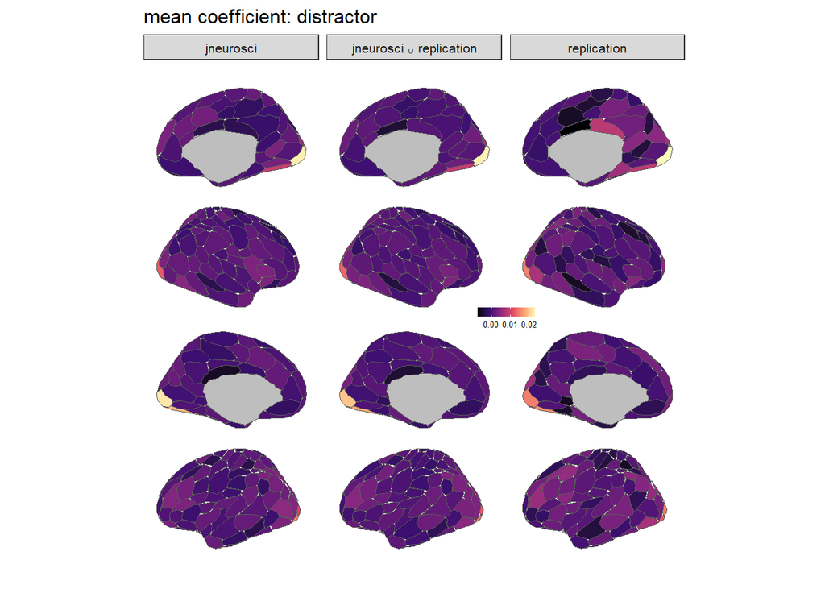

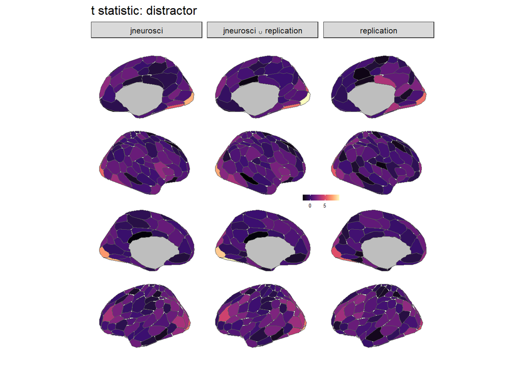

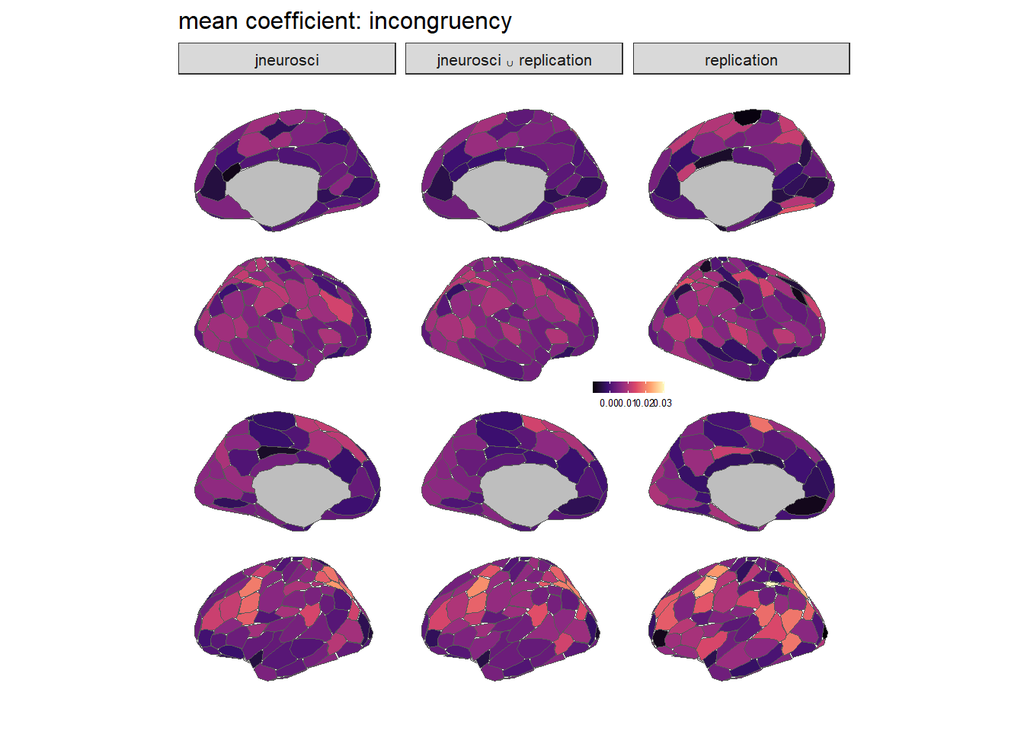

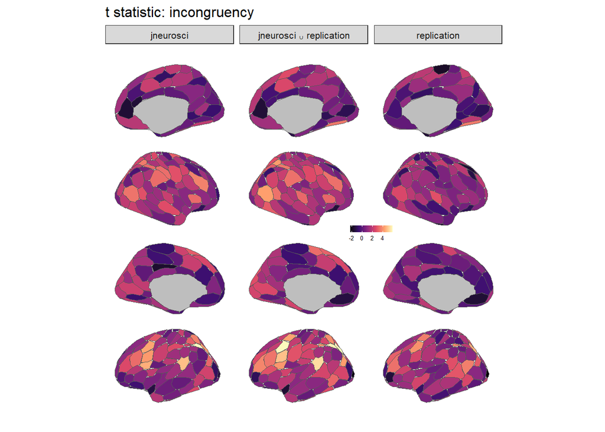

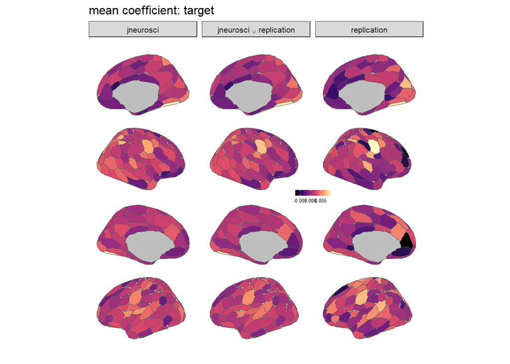

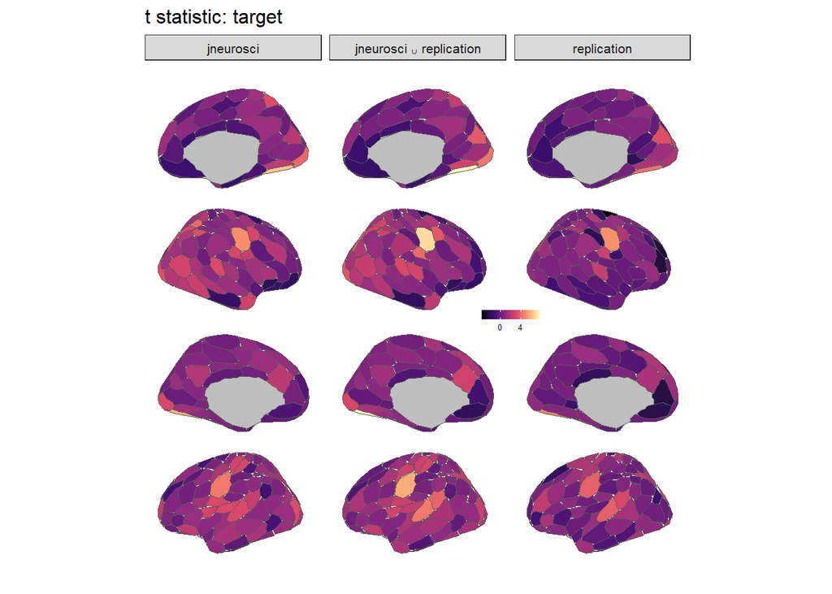

```r
for (model_i in seq_along(models[[measure]])) {

  model <- models[[measure]][model_i]

  for (stat_i in seq_along(statistics)) {

    p <- dat_sum %>%
      filter(term %in% model) %>%
      ggplot() +
      geom_brain(
        aes_string(fill = statistics[stat_i]),
        atlas = atlas, position = position_brain(hemi + side ~ .)
        ) +
      scale_fill_viridis_c(
        option = "magma", na.value = "grey",
        breaks = scales::extended_breaks(4)
        ) +
      facet_grid(cols = vars(subjlist)) +
      theme_surface +
      theme(legend.position = c(2/3, 0.5)) +
      labs(title = paste0(titles[stat_i], ": ", model), fill = NULL)

    print(p)

  }

}
```

## 2.2 Thresholded

Three consecutive thresholds are used, each more liberal than the previous:

- **p_FDR < 0.05**: parcels with mean model fit significantly greater than 0 following FDR correction over all parcels (separately per model)
- **p_uncorr < 0.05**: parcels with mean model fit significantly greater than 0 (uncorrected)
- **t_stat > 0**: parcels with mean model fit numerically greater than zero

### 2.2.1 Common scale

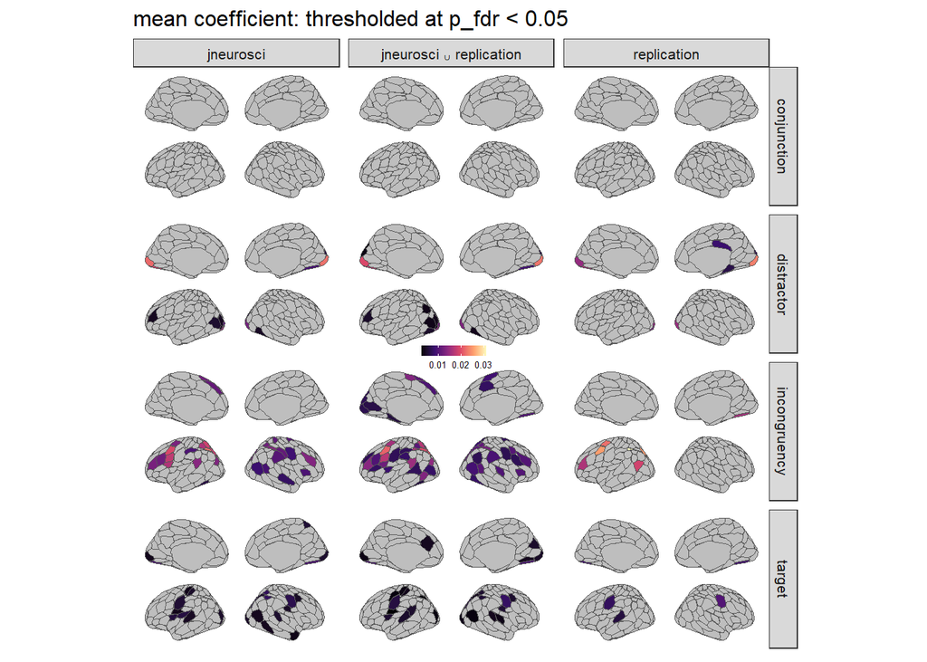

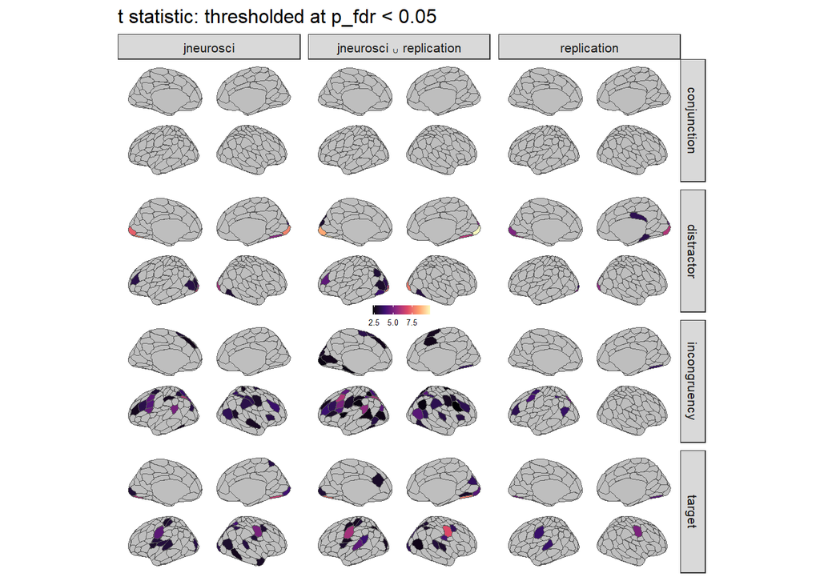

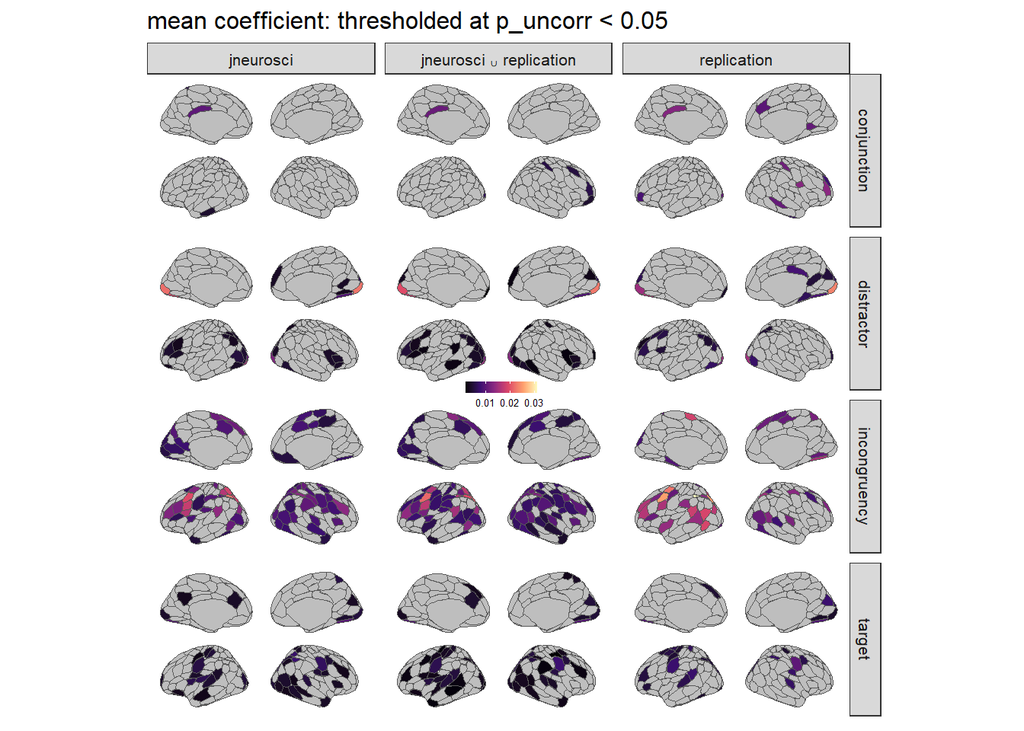

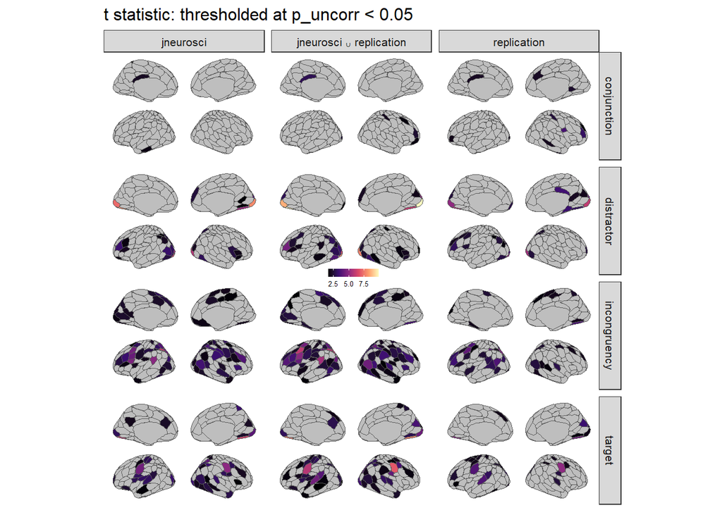

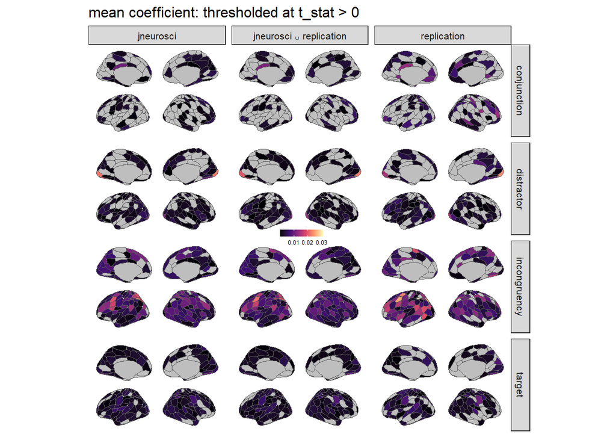

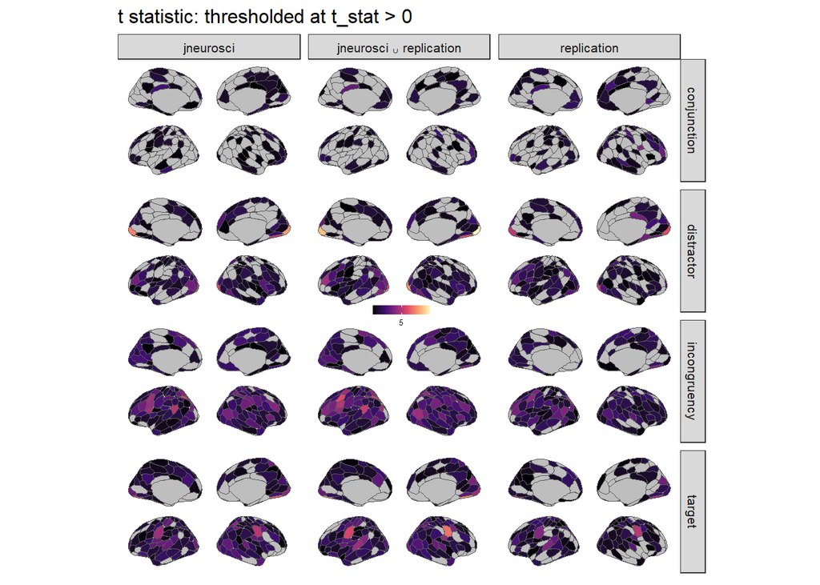

```r
dat_sum$is_in_thresh_fdr <- dat_sum$p_fdr < 0.05
dat_sum$is_in_thresh_p <- dat_sum$p < 0.05
dat_sum$is_in_thresh_sign <- dat_sum$t_stat > 0

thresholds <- c("p_fdr < 0.05", "p_uncorr < 0.05", "t_stat > 0")
thresholds_nms <- c("is_in_thresh_fdr", "is_in_thresh_p", "is_in_thresh_sign")

for (thresh_i in seq_along(thresholds)) {

  threshold_nm <- thresholds_nms[thresh_i]

  for (stat_i in seq_along(statistics)) {

    dat_sum$thresh <- as.numeric(ifelse(dat_sum[[threshold_nm]], dat_sum[[statistics[stat_i]]], NA))

    p <- dat_sum %>%
      ggplot() +
      geom_brain(
        aes(fill = thresh),
        atlas = atlas, position = position_brain(side ~ hemi)
        ) +
      scale_fill_viridis_c(
        option = "magma", na.value = "grey",
        breaks = scales::extended_breaks(4)
        ) +
      facet_grid(rows = vars(term), cols = vars(subjlist)) +
      theme_surface +
      labs(title = paste0(titles[stat_i], ": thresholded at ", thresholds[thresh_i]), fill = NULL)

    print(p)

  }

}
```

# 3 Tables

## 3.1 Do identified parcels replicate?

Parcels within the **jneurosci** sample that survived FDR correction (whole-cortex) are identified. Are these parcels still significant (uncorrected) in the **replication** sample?

Displayed are stats within the replication sample for “successfully replicated” parcels (p<0.05).

```r
sig_orig <- dat_sum %>% filter(p_fdr < 0.05, subjlist == "jneurosci") %>% ungroup %>% select(term, region)

d <- enlist(c("target", "distractor", "incongruency"))
for (model in names(d)) {

  d[[model]] <- dat_sum %>%
    ungroup %>%
    filter(
      subjlist == "replication", term == model, region %in% sig_orig$region[sig_orig$term == model], p < 0.05
    ) %>%
    select(region, m, t_stat, p) %>%
    arrange(region)

}

lapply(d, kable)
```

$target

| region | m | t_stat | p |
| --- | --- | --- | --- |
| 17Networks_LH_SomMotB_Aud_2 | 0.0058689 | 3.706551 | 0.0006979 |
| 17Networks_LH_SomMotB_Cent_1 | 0.0074792 | 3.735322 | 0.0006526 |
| 17Networks_LH_VisCent_ExStr_1 | 0.0090153 | 4.767549 | 0.0000588 |
| 17Networks_RH_DorsAttnA_SPL_1 | 0.0054988 | 2.269865 | 0.0172135 |
| 17Networks_RH_SalVentAttnA_PrC_1 | 0.0057293 | 1.954488 | 0.0323840 |
| 17Networks_RH_SomMotB_Cent_1 | 0.0099970 | 4.994412 | 0.0000348 |
| 17Networks_RH_SomMotB_S2_4 | 0.0071325 | 2.618037 | 0.0082355 |
| 17Networks_RH_VisCent_ExStr_1 | 0.0089979 | 4.301534 | 0.0001738 |
| 17Networks_RH_VisCent_Striate_1 | 0.0037559 | 1.887792 | 0.0368252 |

$distractor

| region | m | t_stat | p |
| --- | --- | --- | --- |
| 17Networks_LH_ContA_PFClv_1 | 0.0058164 | 3.009186 | 0.0034655 |
| 17Networks_LH_VisCent_ExStr_1 | 0.0157273 | 5.599825 | 0.0000088 |
| 17Networks_LH_VisCent_ExStr_2 | 0.0120620 | 4.946874 | 0.0000388 |
| 17Networks_LH_VisCent_ExStr_3 | 0.0144249 | 3.547880 | 0.0010092 |
| 17Networks_LH_VisCent_Striate_1 | 0.0145841 | 5.021691 | 0.0000327 |
| 17Networks_RH_VisCent_ExStr_1 | 0.0085918 | 3.049780 | 0.0031622 |
| 17Networks_RH_VisCent_ExStr_3 | 0.0147546 | 5.340731 | 0.0000158 |
| 17Networks_RH_VisCent_ExStr_5 | 0.0067005 | 4.206411 | 0.0002171 |
| 17Networks_RH_VisCent_Striate_1 | 0.0231490 | 5.999626 | 0.0000036 |

$incongruency

| region | m | t_stat | p |
| --- | --- | --- | --- |
| 17Networks_LH_ContA_IPS_1 | 0.0132986 | 1.926951 | 0.0341567 |
| 17Networks_LH_ContA_PFCl_2 | 0.0156243 | 2.468423 | 0.0113556 |
| 17Networks_LH_ContA_PFCl_3 | 0.0252484 | 4.033186 | 0.0003255 |
| 17Networks_LH_ContA_PFClv_1 | 0.0162733 | 3.383933 | 0.0014743 |
| 17Networks_LH_DefaultC_IPL_1 | 0.0167057 | 2.950179 | 0.0039569 |
| 17Networks_LH_DorsAttnA_SPL_1 | 0.0247787 | 4.605979 | 0.0000855 |
| 17Networks_LH_DorsAttnB_FEF_1 | 0.0220542 | 3.630557 | 0.0008329 |
| 17Networks_LH_SomMotB_Aud_3 | 0.0178586 | 2.749433 | 0.0061809 |
| 17Networks_RH_DorsAttnA_ParOcc_1 | 0.0105864 | 2.558756 | 0.0093604 |
| 17Networks_RH_DorsAttnA_SPL_3 | 0.0093433 | 2.313677 | 0.0157212 |
| 17Networks_RH_TempPar_3 | 0.0129178 | 1.945610 | 0.0329464 |

## 3.2 FDR significant parcels in the full dataset

Displayed are parcels that are significant after FDR correction (whole-cortex) in the higher-powered jneurosci+replication sample.

```r
sig_all <- dat_sum %>%
  filter(p_fdr < 0.05, !subjlist %in% c("jneurosci", "replication")) %>%
  ungroup %>%
  select(term, region)

d <- enlist(c("target", "distractor", "incongruency"))
for (model in names(d)) {

  d[[model]] <- dat_sum %>%
    ungroup %>%
    filter(
      !subjlist %in% c("jneurosci", "replication"),
      term == model,
      region %in% sig_all$region[sig_all$term == model],
      p_fdr < 0.05
    ) %>%
    select(region, m, t_stat, p) %>%
    arrange(region)

}

lapply(d, kable)
```

$target

| region | m | t_stat | p |
| --- | --- | --- | --- |
| 17Networks_LH_ContA_IPS_1 | 0.0030635 | 2.528249 | 0.0069317 |
| 17Networks_LH_SalVentAttnA_FrOper_1 | 0.0051908 | 2.869190 | 0.0027611 |
| 17Networks_LH_SalVentAttnB_PFCmp_1 | 0.0041210 | 2.795287 | 0.0033917 |
| 17Networks_LH_SomMotA_2 | 0.0037896 | 2.954588 | 0.0021681 |
| 17Networks_LH_SomMotA_3 | 0.0033637 | 2.667443 | 0.0048027 |
| 17Networks_LH_SomMotB_Aud_2 | 0.0048075 | 4.392565 | 0.0000208 |
| 17Networks_LH_SomMotB_Aud_3 | 0.0049426 | 3.822991 | 0.0001473 |
| 17Networks_LH_SomMotB_Cent_1 | 0.0059873 | 5.759703 | 0.0000001 |
| 17Networks_LH_SomMotB_Cent_2 | 0.0031285 | 2.707846 | 0.0043074 |
| 17Networks_LH_SomMotB_S2_2 | 0.0027797 | 2.664924 | 0.0048352 |
| 17Networks_LH_VisCent_ExStr_1 | 0.0092040 | 7.523112 | 0.0000000 |
| 17Networks_LH_VisCent_ExStr_4 | 0.0031787 | 2.645970 | 0.0050865 |
| 17Networks_LH_VisCent_Striate_1 | 0.0034021 | 2.996624 | 0.0019217 |
| 17Networks_RH_ContA_IPS_1 | 0.0040790 | 2.830884 | 0.0030731 |
| 17Networks_RH_ContB_IPL_2 | 0.0053271 | 2.776617 | 0.0035707 |
| 17Networks_RH_DorsAttnA_ParOcc_1 | 0.0031524 | 2.519884 | 0.0070834 |
| 17Networks_RH_DorsAttnA_SPL_1 | 0.0061032 | 3.775554 | 0.0001723 |
| 17Networks_RH_DorsAttnA_SPL_2 | 0.0047840 | 3.279842 | 0.0008303 |
| 17Networks_RH_DorsAttnA_SPL_3 | 0.0050111 | 2.946832 | 0.0022166 |
| 17Networks_RH_SalVentAttnA_PrC_1 | 0.0048965 | 3.530509 | 0.0003808 |
| 17Networks_RH_SomMotB_Aud_1 | 0.0035480 | 2.870033 | 0.0027546 |
| 17Networks_RH_SomMotB_Aud_2 | 0.0039614 | 3.070650 | 0.0015501 |
| 17Networks_RH_SomMotB_Cent_1 | 0.0077440 | 6.854120 | 0.0000000 |
| 17Networks_RH_SomMotB_S2_4 | 0.0053579 | 3.986551 | 0.0000851 |
| 17Networks_RH_VisCent_ExStr_1 | 0.0093211 | 7.681174 | 0.0000000 |
| 17Networks_RH_VisCent_ExStr_3 | 0.0036973 | 3.424933 | 0.0005309 |
| 17Networks_RH_VisCent_Striate_1 | 0.0045875 | 4.286641 | 0.0000302 |
| 17Networks_RH_VisPeri_ExStrInf_1 | 0.0039904 | 2.807373 | 0.0032803 |
| 17Networks_RH_VisPeri_ExStrSup_2 | 0.0047263 | 3.560217 | 0.0003465 |

$distractor

| region | m | t_stat | p |
| --- | --- | --- | --- |
| 17Networks_LH_ContA_PFClv_1 | 0.0046494 | 4.421297 | 0.0000187 |
| 17Networks_LH_DefaultA_IPL_1 | 0.0035759 | 2.996141 | 0.0019244 |
| 17Networks_LH_DorsAttnA_ParOcc_1 | 0.0036084 | 2.866932 | 0.0027787 |
| 17Networks_LH_DorsAttnA_TempOcc_2 | 0.0047163 | 3.728850 | 0.0002009 |
| 17Networks_LH_VisCent_ExStr_1 | 0.0178035 | 9.627612 | 0.0000000 |
| 17Networks_LH_VisCent_ExStr_2 | 0.0141423 | 8.067382 | 0.0000000 |
| 17Networks_LH_VisCent_ExStr_3 | 0.0115560 | 6.244228 | 0.0000000 |
| 17Networks_LH_VisCent_ExStr_4 | 0.0038232 | 3.335025 | 0.0007014 |
| 17Networks_LH_VisCent_ExStr_5 | 0.0043901 | 3.143699 | 0.0012499 |
| 17Networks_LH_VisCent_Striate_1 | 0.0194289 | 8.513103 | 0.0000000 |
| 17Networks_LH_VisPeri_ExStrSup_2 | 0.0032699 | 2.885007 | 0.0026411 |
| 17Networks_RH_DorsAttnA_TempOcc_1 | 0.0039449 | 3.153635 | 0.0012136 |
| 17Networks_RH_VisCent_ExStr_1 | 0.0089830 | 6.053387 | 0.0000000 |
| 17Networks_RH_VisCent_ExStr_3 | 0.0130397 | 7.684133 | 0.0000000 |
| 17Networks_RH_VisCent_ExStr_5 | 0.0061881 | 5.057176 | 0.0000018 |
| 17Networks_RH_VisCent_Striate_1 | 0.0224580 | 9.899897 | 0.0000000 |

$incongruency

| region | m | t_stat | p |
| --- | --- | --- | --- |
| 17Networks_LH_ContA_IPS_1 | 0.0194085 | 5.793119 | 0.0000001 |
| 17Networks_LH_ContA_IPS_2 | 0.0160189 | 4.168602 | 0.0000456 |
| 17Networks_LH_ContA_IPS_3 | 0.0104784 | 2.471992 | 0.0080112 |
| 17Networks_LH_ContA_PFCl_1 | 0.0097912 | 3.466529 | 0.0004661 |
| 17Networks_LH_ContA_PFCl_2 | 0.0169322 | 4.906889 | 0.0000032 |
| 17Networks_LH_ContA_PFCl_3 | 0.0211946 | 5.935380 | 0.0000001 |
| 17Networks_LH_ContA_PFClv_1 | 0.0137533 | 3.809405 | 0.0001541 |
| 17Networks_LH_ContA_Temp_1 | 0.0132228 | 3.201940 | 0.0010506 |
| 17Networks_LH_DefaultB_PFCd_3 | 0.0095492 | 2.548640 | 0.0065741 |
| 17Networks_LH_DefaultB_PFCd_4 | 0.0105931 | 3.127267 | 0.0013123 |
| 17Networks_LH_DefaultB_PFCv_4 | 0.0076839 | 2.798876 | 0.0033583 |
| 17Networks_LH_DefaultC_IPL_1 | 0.0142585 | 4.301162 | 0.0000287 |
| 17Networks_LH_DefaultC_PHC_1 | 0.0058216 | 2.397123 | 0.0096817 |
| 17Networks_LH_DorsAttnA_ParOcc_1 | 0.0078645 | 2.480712 | 0.0078346 |
| 17Networks_LH_DorsAttnA_SPL_1 | 0.0201802 | 5.962237 | 0.0000001 |
| 17Networks_LH_DorsAttnA_SPL_2 | 0.0099968 | 2.799256 | 0.0033547 |
| 17Networks_LH_DorsAttnA_SPL_3 | 0.0168883 | 3.965912 | 0.0000913 |
| 17Networks_LH_DorsAttnA_TempOcc_1 | 0.0059954 | 2.673096 | 0.0047304 |
| 17Networks_LH_DorsAttnB_FEF_1 | 0.0156119 | 4.415939 | 0.0000191 |
| 17Networks_LH_DorsAttnB_PostC_1 | 0.0072978 | 2.534723 | 0.0068163 |
| 17Networks_LH_SalVentAttnA_FrMed_2 | 0.0133003 | 3.291512 | 0.0008013 |
| 17Networks_LH_SalVentAttnA_FrOper_1 | 0.0082832 | 2.390391 | 0.0098462 |
| 17Networks_LH_SalVentAttnA_FrOper_2 | 0.0118065 | 4.135260 | 0.0000512 |
| 17Networks_LH_SalVentAttnA_ParOper_1 | 0.0078759 | 2.416003 | 0.0092334 |
| 17Networks_LH_SalVentAttnB_PFCl_1 | 0.0072708 | 2.646731 | 0.0050762 |
| 17Networks_LH_SomMotB_Aud_3 | 0.0150634 | 5.390721 | 0.0000005 |
| 17Networks_LH_SomMotB_Cent_1 | 0.0072328 | 2.811740 | 0.0032408 |
| 17Networks_LH_TempPar_1 | 0.0072899 | 2.466027 | 0.0081341 |
| 17Networks_LH_VisCent_Striate_1 | 0.0067487 | 2.417233 | 0.0092048 |
| 17Networks_LH_VisPeri_ExStrSup_2 | 0.0069450 | 2.735299 | 0.0039981 |
| 17Networks_LH_VisPeri_StriCal_1 | 0.0064300 | 2.556968 | 0.0064328 |
| 17Networks_RH_ContA_IPS_1 | 0.0105980 | 2.968698 | 0.0020823 |
| 17Networks_RH_ContA_IPS_2 | 0.0124216 | 3.522011 | 0.0003912 |
| 17Networks_RH_ContA_PFCl_1 | 0.0070908 | 2.297161 | 0.0123947 |
| 17Networks_RH_ContA_PFCl_2 | 0.0098893 | 3.361159 | 0.0006471 |
| 17Networks_RH_DefaultA_IPL_1 | 0.0070275 | 2.407032 | 0.0094440 |
| 17Networks_RH_DorsAttnA_ParOcc_1 | 0.0090660 | 4.321464 | 0.0000267 |
| 17Networks_RH_DorsAttnA_SPL_1 | 0.0107657 | 3.188947 | 0.0010923 |
| 17Networks_RH_DorsAttnA_SPL_2 | 0.0143298 | 3.957422 | 0.0000939 |
| 17Networks_RH_DorsAttnA_SPL_3 | 0.0110497 | 4.271918 | 0.0000318 |
| 17Networks_RH_DorsAttnA_SPL_4 | 0.0086297 | 2.722590 | 0.0041387 |
| 17Networks_RH_DorsAttnA_TempOcc_1 | 0.0078254 | 2.990400 | 0.0019565 |
| 17Networks_RH_DorsAttnB_PostC_4 | 0.0068360 | 2.393825 | 0.0097620 |
| 17Networks_RH_SalVentAttnA_FrMed_1 | 0.0076290 | 2.567732 | 0.0062544 |
| 17Networks_RH_SalVentAttnA_FrMed_2 | 0.0088044 | 2.681476 | 0.0046250 |
| 17Networks_RH_SalVentAttnA_ParOper_1 | 0.0093141 | 3.395521 | 0.0005818 |
| 17Networks_RH_SalVentAttnA_PrC_1 | 0.0101902 | 2.842638 | 0.0029741 |
| 17Networks_RH_SalVentAttnB_Ins_2 | 0.0099647 | 3.172493 | 0.0011473 |
| 17Networks_RH_SomMotA_8 | 0.0073190 | 2.423161 | 0.0090683 |
| 17Networks_RH_SomMotB_Aud_1 | 0.0096876 | 3.216058 | 0.0010070 |
| 17Networks_RH_SomMotB_Cent_1 | 0.0069277 | 2.672221 | 0.0047415 |
| 17Networks_RH_TempPar_3 | 0.0103616 | 3.388983 | 0.0005937 |
| 17Networks_RH_VisCent_ExStr_1 | 0.0097956 | 3.519828 | 0.0003939 |

## 3.3 ROI-based analysis

Which ROIs (parcels) survive FDR correction over the reduced set of 10 ROIs? This is tested separately for each subject set (jneuro, replication, jneuro+replication).

```r
dat_sum_rois <- dat_sum %>% filter(region %in% rois$region) %>% mutate(p_fdr = p.adjust(p, "fdr"))

d <- enlist(c("target", "distractor", "incongruency"))
for (model in names(d)) {

  d[[model]] <- dat_sum_rois %>%
    ungroup %>%
    filter(term == model, p_fdr < 0.05) %>%
    select(region, subjlist, m, t_stat, p, p_fdr) %>%
    arrange(region, subjlist)
}

lapply(d, kable)
```

$target

| region | subjlist | m | t_stat | p | p_fdr |
| --- | --- | --- | --- | --- | --- |
| 17Networks_LH_SalVentAttnB_PFCmp_1 | jneurosci ∪ replication | 0.004121 | 2.795287 | 0.0033917 | 0.0339171 |

$distractor

| region | subjlist | m | t_stat | p | p_fdr |
| --- | --- | --- | --- | --- | --- |
| 17Networks_LH_ContA_PFCl_1 | jneurosci ∪ replication | 0.0030942 | 2.338522 | 0.0111995 | 0.0373318 |
| 17Networks_LH_ContA_PFCl_3 | jneurosci ∪ replication | 0.0030191 | 2.500519 | 0.0074462 | 0.0372311 |
| 17Networks_LH_ContA_PFClv_1 | jneurosci | 0.0041167 | 3.270700 | 0.0010312 | 0.0103122 |
| 17Networks_LH_ContA_PFClv_1 | jneurosci ∪ replication | 0.0046494 | 4.421297 | 0.0000187 | 0.0001874 |
| 17Networks_LH_ContA_PFClv_1 | replication | 0.0058164 | 3.009186 | 0.0034655 | 0.0346552 |

$incongruency

| region | subjlist | m | t_stat | p | p_fdr |
| --- | --- | --- | --- | --- | --- |
| 17Networks_LH_ContA_PFCl_1 | jneurosci | 0.0119714 | 3.290624 | 0.0009742 | 0.0024355 |
| 17Networks_LH_ContA_PFCl_1 | jneurosci ∪ replication | 0.0097912 | 3.466529 | 0.0004661 | 0.0011652 |
| 17Networks_LH_ContA_PFCl_2 | jneurosci | 0.0175293 | 4.216589 | 0.0000591 | 0.0002953 |
| 17Networks_LH_ContA_PFCl_2 | jneurosci ∪ replication | 0.0169322 | 4.906889 | 0.0000032 | 0.0000159 |
| 17Networks_LH_ContA_PFCl_2 | replication | 0.0156243 | 2.468423 | 0.0113556 | 0.0378522 |
| 17Networks_LH_ContA_PFCl_3 | jneurosci | 0.0193440 | 4.432523 | 0.0000296 | 0.0002953 |
| 17Networks_LH_ContA_PFCl_3 | jneurosci ∪ replication | 0.0211946 | 5.935380 | 0.0000001 | 0.0000006 |
| 17Networks_LH_ContA_PFCl_3 | replication | 0.0252484 | 4.033186 | 0.0003255 | 0.0032550 |
| 17Networks_LH_ContA_PFClv_1 | jneurosci | 0.0126028 | 2.624520 | 0.0059047 | 0.0118095 |
| 17Networks_LH_ContA_PFClv_1 | jneurosci ∪ replication | 0.0137533 | 3.809405 | 0.0001541 | 0.0005137 |
| 17Networks_LH_ContA_PFClv_1 | replication | 0.0162733 | 3.383933 | 0.0014743 | 0.0073714 |
| 17Networks_LH_SalVentAttnA_FrMed_1 | jneurosci | 0.0089769 | 2.202663 | 0.0163912 | 0.0234882 |
| 17Networks_LH_SalVentAttnA_FrMed_1 | jneurosci ∪ replication | 0.0065678 | 2.136738 | 0.0181652 | 0.0227065 |
| 17Networks_RH_ContA_PFCl_1 | jneurosci | 0.0080649 | 1.980930 | 0.0268653 | 0.0335816 |
| 17Networks_RH_ContA_PFCl_1 | jneurosci ∪ replication | 0.0070908 | 2.297161 | 0.0123947 | 0.0177067 |
| 17Networks_RH_ContA_PFCl_2 | jneurosci | 0.0133500 | 3.718780 | 0.0002764 | 0.0009212 |
| 17Networks_RH_ContA_PFCl_2 | jneurosci ∪ replication | 0.0098893 | 3.361159 | 0.0006471 | 0.0012943 |
| 17Networks_RH_SalVentAttnA_FrMed_1 | jneurosci | 0.0083912 | 2.201322 | 0.0164418 | 0.0234882 |
| 17Networks_RH_SalVentAttnA_FrMed_1 | jneurosci ∪ replication | 0.0076290 | 2.567732 | 0.0062544 | 0.0104240 |

# 4 Bar plots

```r
## prep for plotting:

dat_subjs_barplots <- dat_subjs %>%
  mutate(
    term = factor(term, levels = c("target", "incongruency", "distractor")),
    region_nice = gsub("17Networks_", "", region)
    ) %>%
  filter(term %in% c("target", "distractor", "incongruency"))
```

## 4.1 ROIs

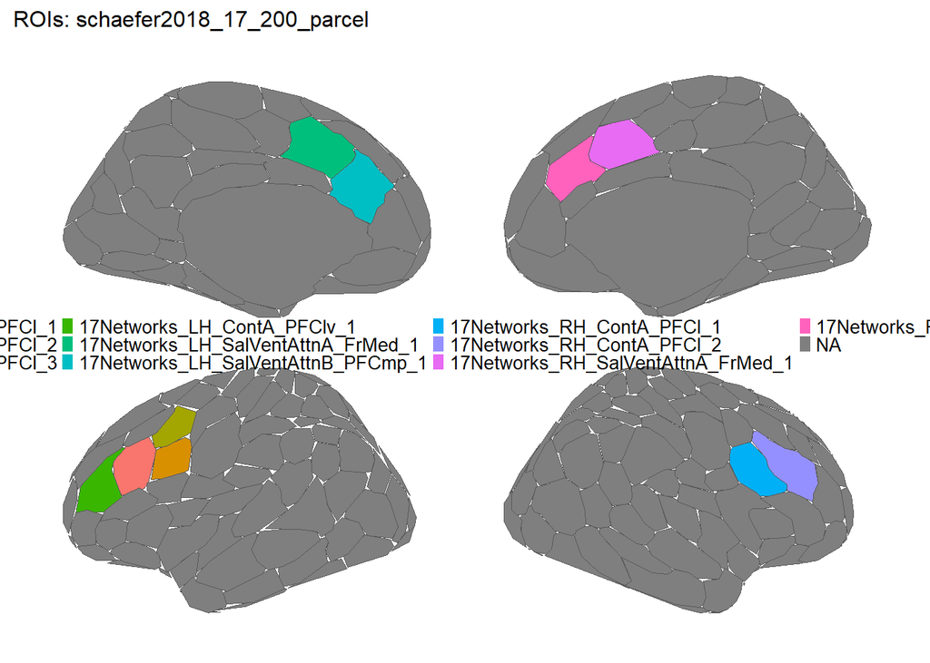

```r
atlas$data %>%
  ggplot() +
    geom_brain(
      aes(fill = ifelse(region %in% rois$region, region, NA)),
      atlas = atlas, position = position_brain(side ~ hemi)
      ) +
  labs(title = paste0("ROIs: ", roiset), fill = NULL) +
  theme_surface +
  theme(legend.text = element_text(size = 10))
```

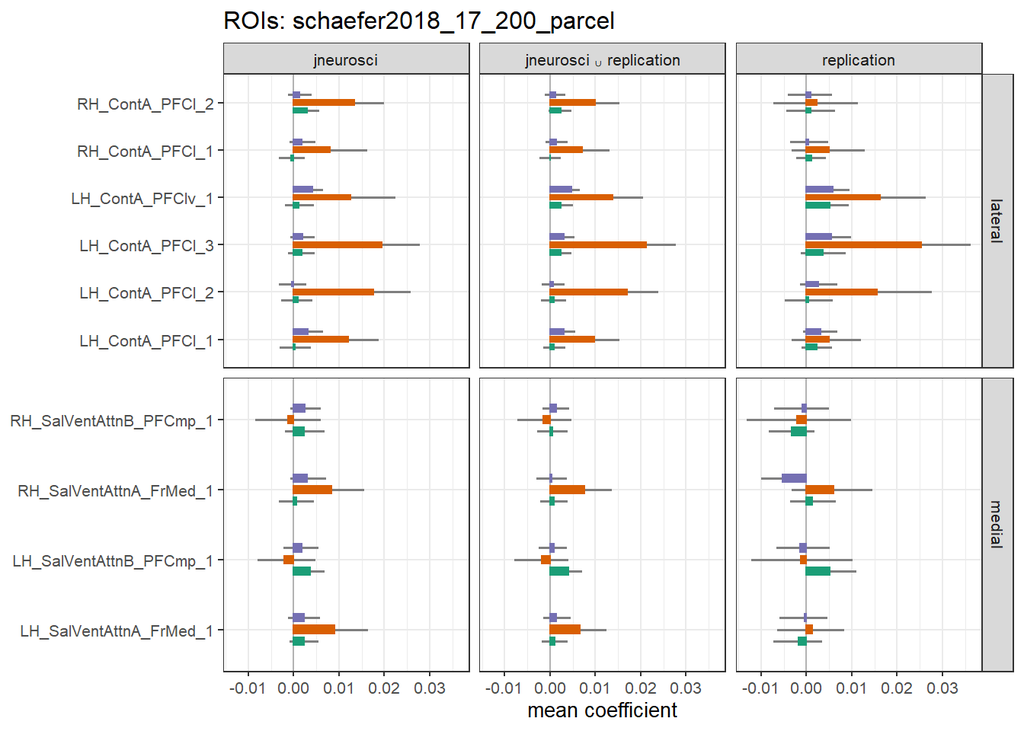

```r
dat_subjs_barplots %>%

  right_join(rois, by = "region") %>%

  ggplot(aes(region_nice, b, fill = term, color = term)) +
  geom_hline(yintercept = 0, color = "grey70") +
  stat_summary(
    fun.data = mean_cl_boot, geom = "errorbar", width = 0, size = 2/3, position = position_dodge(width = 0.5),
    color = "grey50"
    ) +
  stat_summary(fun = mean, geom = "col", width = 1/3, position = position_dodge(width = 0.5)) +

  scale_color_brewer(type = "qual", palette = 2) +
  scale_fill_brewer(type = "qual", palette = 2) +

  facet_grid(cols = vars(subjlist), rows = vars(location), scales = "free_y") +
  theme(
    #axis.text.x = element_text(angle = 90, hjust = 1, vjust = 0.5),
    legend.position = "none", axis.title.y = element_blank()
    ) +
    labs(y = "mean coefficient", title = paste0("ROIs: ", roiset)) +
  coord_flip()
```